# Assignment 2

Trevor Baker

23/09/2019

## EXERCISE 1

#### Basic ‘dplyr’

**1.1**

```r
knitr::kable(
  gapminder %>%
    filter(between(year,1970,1980) & (country=="China" | country=="Canada" | country=="United States"))
)
```

| country | continent | year | lifeExp | pop | gdpPercap |
| --- | --- | --- | --- | --- | --- |
| Canada | Americas | 1972 | 72.88000 | 22284500 | 18970.5709 |
| Canada | Americas | 1977 | 74.21000 | 23796400 | 22090.8831 |
| China | Asia | 1972 | 63.11888 | 862030000 | 676.9001 |
| China | Asia | 1977 | 63.96736 | 943455000 | 741.2375 |
| United States | Americas | 1972 | 71.34000 | 209896000 | 21806.0359 |
| United States | Americas | 1977 | 73.38000 | 220239000 | 24072.6321 |

**1.2**

```r
knitr::kable(
  gapminder %>%
    filter(between(year,1970,1980) & (country=="China" | country=="Canada" | country=="United States")) %>%
    select(country, gdpPercap)
)
```

| country | gdpPercap |
| --- | --- |
| Canada | 18970.5709 |
| Canada | 22090.8831 |
| China | 676.9001 |
| China | 741.2375 |
| United States | 21806.0359 |
| United States | 24072.6321 |

**1.3**

```r
DT::datatable(
  gapminder %>%
    group_by(country) %>%
    mutate(lifeExp.incr=round(lifeExp-lag(lifeExp),2) ) %>%
    filter(lifeExp.incr<0) %>%
    arrange(lifeExp.incr)
)
```

|  | country | continent | year | lifeExp | pop | gdpPercap | lifeExp.incr |
| --- | --- | --- | --- | --- | --- | --- | --- |
| 1 | Rwanda | Africa | 1992 | 23.599 | 7290203 | 737.0685949 | -20.42 |
| 2 | Zimbabwe | Africa | 1997 | 46.809 | 11404948 | 792.4499603 | -13.57 |
| 3 | Lesotho | Africa | 2002 | 44.593 | 2046772 | 1275.184575 | -10.96 |
| 4 | Swaziland | Africa | 2002 | 43.869 | 1130269 | 4128.116943 | -10.42 |
| 5 | Botswana | Africa | 1997 | 52.556 | 1536536 | 8647.142313 | -10.19 |
| 6 | Cambodia | Asia | 1977 | 31.22 | 6978607 | 524.9721832 | -9.1 |
| 7 | Namibia | Africa | 2002 | 51.479 | 1972153 | 4072.324751 | -7.43 |
| 8 | South Africa | Africa | 2002 | 53.365 | 44433622 | 7710.946444 | -6.87 |
| 9 | Zimbabwe | Africa | 2002 | 39.989 | 11926563 | 672.0386227 | -6.82 |
| 10 | China | Asia | 1962 | 44.50136 | 665770000 | 487.6740183 | -6.05 |

[output cut: 91 more lines]

**1.4**

```r
DT::datatable(
  gapminder %>%
    group_by(country) %>%
    summarize(max.gdp=max(gdpPercap) %>% round(digits=0)) %>%
    arrange(desc(max.gdp))
)
```

|  | country | max.gdp |
| --- | --- | --- |
| 1 | Kuwait | 113523 |
| 2 | Norway | 49357 |
| 3 | Singapore | 47143 |
| 4 | United States | 42952 |
| 5 | Ireland | 40676 |
| 6 | Hong Kong, China | 39725 |
| 7 | Switzerland | 37506 |
| 8 | Netherlands | 36798 |
| 9 | Canada | 36319 |
| 10 | Iceland | 36181 |

[output cut: 132 more lines]

**1.5**

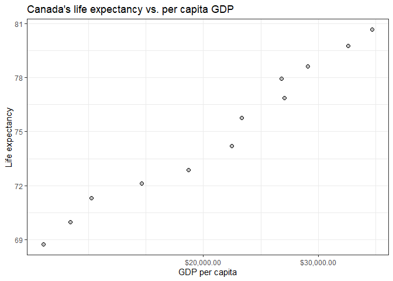

```r
gapminder %>%
  filter(country=="Canada") %>%
  ggplot(aes(x=gdpPercap,y=lifeExp)) +
            geom_point(pch=21,cex=2, bg="grey") +
            scale_x_log10("GDP per capita", labels = scales::dollar_format()) +
            ylab("Life expectancy") +
            ggtitle("Canada's life expectancy vs. per capita GDP") +
            theme_bw()
```

## EXERCISE 2

#### Explore individual variables with ‘dplyr’

I have chosen life expectancy and continent to summarize here.

There are 5 continents in the dataset:

```r
#display all continents - kind of useless
knitr::kable(
  gapminder %>%
    select(continent) %>%
    unique()
)
```

| continent |
| --- |
| Asia |
| Europe |
| Africa |
| Americas |
| Oceania |

Here are some summary stats on global life expectancies:

```r
#display range of lifeExp data globally:

# #method 1
# knitr::kable(
#   gapminder %>%
#     select(lifeExp) %>%
#     summarize(min.lifeExp=min(lifeExp)%>% round(digits=1),
#               Q1.lifeExp=quantile(lifeExp, 0.25) %>% round(digits=1),
#               median.lifeExp=median(lifeExp)%>% round(digits=1),
#               mean.lifeExp=mean(lifeExp)%>% round(digits=1),
#               Q3.lifeExp=quantile(lifeExp, 0.75) %>% round(digits=1),
#               max.lifeExp=max(lifeExp) %>% round(digits=1))
# )

#method 2
knitr::kable(
  gapminder %>%
    select(lifeExp) %>%
    summary()
)
```

|  | lifeExp |
| --- | --- |
|  | Min. :23.60 |
|  | 1st Qu.:48.20 |
|  | Median :60.71 |
|  | Mean :59.47 |
|  | 3rd Qu.:70.85 |
|  | Max. :82.60 |

It is more informative to see these summary statistics divided up by continent:

```r
#display range of lifeExp data by continent

# #method 1
# knitr::kable(
#   gapminder %>%
#     select(continent, lifeExp) %>%
#     group_by(continent) %>%
#     summarize(min.lifeExp=min(lifeExp)%>% round(digits=1),
#               Q1.lifeExp=quantile(lifeExp, 0.25) %>% round(digits=1),
#               median.lifeExp=median(lifeExp)%>% round(digits=1),
#               mean.lifeExp=mean(lifeExp)%>% round(digits=1),
#               Q3.lifeExp=quantile(lifeExp, 0.75) %>% round(digits=1),
#               max.lifeExp=max(lifeExp) %>% round(digits=1))
# )

#method 2
knitr::kable(
  gapminder %>%
    select(continent, lifeExp) %>%
    group_by(continent) %>%
    summarize(summ=list(c(summary(lifeExp) %>% round(digits=1)))) %>%
    unnest_wider(summ)
)
```

| continent | Min. | 1st Qu. | Median | Mean | 3rd Qu. | Max. |
| --- | --- | --- | --- | --- | --- | --- |
| Africa | 23.6 | 42.4 | 47.8 | 48.9 | 54.4 | 76.4 |
| Americas | 37.6 | 58.4 | 67.0 | 64.7 | 71.7 | 80.7 |
| Asia | 28.8 | 51.4 | 61.8 | 60.1 | 69.5 | 82.6 |
| Europe | 43.6 | 69.6 | 72.2 | 71.9 | 75.5 | 81.8 |
| Oceania | 69.1 | 71.2 | 73.7 | 74.3 | 77.6 | 81.2 |

It’s probably even more informative to see life expectancies graphed:

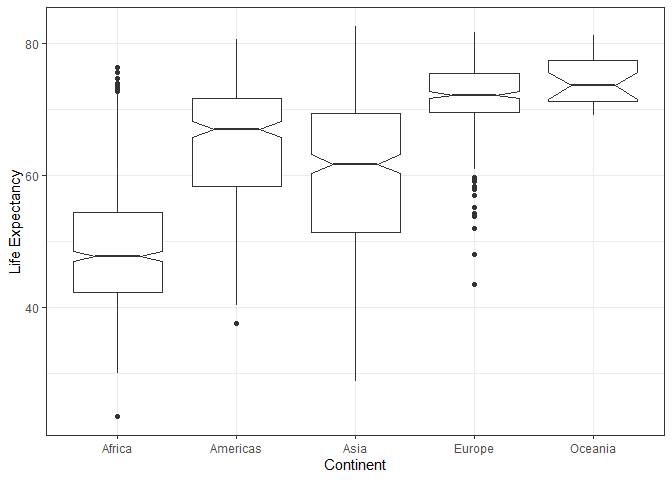

```r
#display range of both variables via boxplot
gapminder %>%
  select(continent, lifeExp) %>%
  group_by(continent) %>%
  ggplot(aes(x=continent, y=lifeExp)) +
    geom_boxplot(notch=T) +
    ylab("Life Expectancy") +
    xlab("Continent") +
    theme_bw()
```

## EXERCISE 3

#### Explore various plot types

**Plot 1**

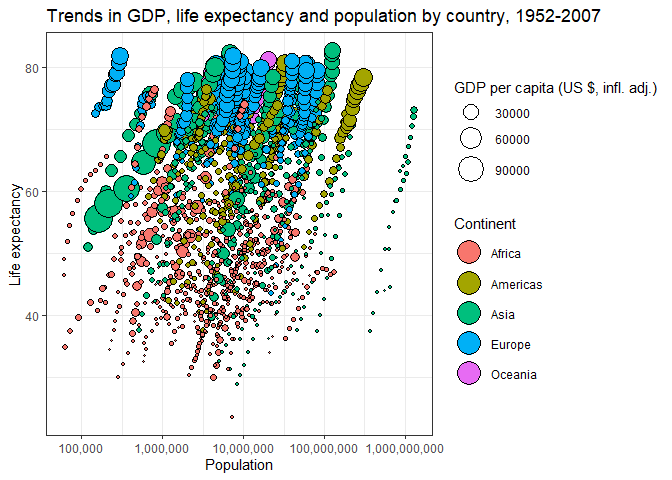

```r
gapminder %>%
  ggplot(aes(x=pop, y=lifeExp, size=gdpPercap, fill=continent)) +
    geom_point(pch=21,colour="black") +
    scale_x_log10("Population", labels=scales::comma) +
    ylab("Life expectancy") +
    theme_bw() +
    scale_size_continuous(name="GDP per capita (US $, infl. adj.)", range=c(0.5,10)) +
    scale_fill_discrete(name="Continent") +
    guides(fill = guide_legend(override.aes = list(size=8))) +
    labs(title="Trends in GDP, life expectancy and population by country, 1952-2007")
```

**Plot 2**

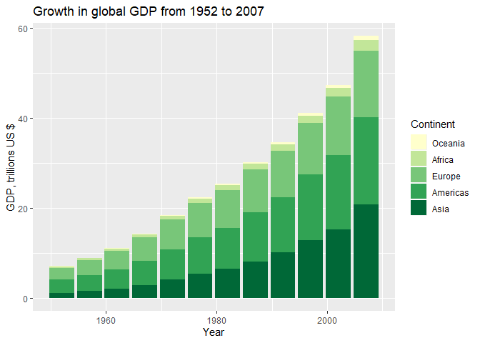

```r
gapminder %>%
  mutate(gdp=gdpPercap*pop) %>%
  mutate(continent=factor(continent, #put small ones on top
                          levels=c("Oceania","Africa","Europe","Americas","Asia"))) %>%
  group_by(continent, year) %>%
  summarize(gdp.cont=sum(gdp)/1e12) %>%
  ggplot(aes(x=year, y=gdp.cont, fill=continent)) +
    geom_col() +
    scale_fill_brewer(palette="YlGn",
                      name="Continent") +
    scale_y_continuous(name="GDP, trillions US $") +
    scale_x_continuous(name="Year") +
    labs(title="Growth in global GDP from 1952 to 2007")
```

**Evaluate extra code**

Original code:

```r
filter(gapminder, country == c("Rwanda", "Afghanistan"))
```

```
## # A tibble: 12 x 6
##    country     continent  year lifeExp      pop gdpPercap
##    <fct>       <fct>     <int>   <dbl>    <int>     <dbl>
##  1 Afghanistan Asia       1957    30.3  9240934      821.
##  2 Afghanistan Asia       1967    34.0 11537966      836.
##  3 Afghanistan Asia       1977    38.4 14880372      786.
##  4 Afghanistan Asia       1987    40.8 13867957      852.
##  5 Afghanistan Asia       1997    41.8 22227415      635.
##  6 Afghanistan Asia       2007    43.8 31889923      975.
##  7 Rwanda      Africa     1952    40    2534927      493.
##  8 Rwanda      Africa     1962    43    3051242      597.
##  9 Rwanda      Africa     1972    44.6  3992121      591.
## 10 Rwanda      Africa     1982    46.2  5507565      882.
## 11 Rwanda      Africa     1992    23.6  7290203      737.
## 12 Rwanda      Africa     2002    43.4  7852401      786.
```

The analyst’s intent was to get all rows of data for Rwanda and Afghanistan. They did not succeed because they provided a vector with length of 2 to the filter function, which was run through sequentially by R because R recycles vectors. The code’s output was to retrieve the first result for Rwanda, the second result for Afghanistan, the third result for Rwanda, and so on.

A better way to do this would be to use filter to select all rows where the country is Rwanda or the country is Afghanistan:

```r
DT::datatable(
  filter(gapminder, country == "Rwanda" | country=="Afghanistan")
)
```

|  | country | continent | year | lifeExp | pop | gdpPercap |
| --- | --- | --- | --- | --- | --- | --- |
| 1 | Afghanistan | Asia | 1952 | 28.801 | 8425333 | 779.4453145 |
| 2 | Afghanistan | Asia | 1957 | 30.332 | 9240934 | 820.8530296 |
| 3 | Afghanistan | Asia | 1962 | 31.997 | 10267083 | 853.10071 |
| 4 | Afghanistan | Asia | 1967 | 34.02 | 11537966 | 836.1971382 |
| 5 | Afghanistan | Asia | 1972 | 36.088 | 13079460 | 739.9811058 |
| 6 | Afghanistan | Asia | 1977 | 38.438 | 14880372 | 786.11336 |
| 7 | Afghanistan | Asia | 1982 | 39.854 | 12881816 | 978.0114388 |
| 8 | Afghanistan | Asia | 1987 | 40.822 | 13867957 | 852.3959448 |
| 9 | Afghanistan | Asia | 1992 | 41.674 | 16317921 | 649.3413952 |
| 10 | Afghanistan | Asia | 1997 | 41.763 | 22227415 | 635.341351 |

[output cut: 14 more lines]

The same code can be written using the pipe operator:

```r
DT::datatable(
  gapminder %>%
    filter(country == "Rwanda" | country=="Afghanistan")
)
```

|  | country | continent | year | lifeExp | pop | gdpPercap |
| --- | --- | --- | --- | --- | --- | --- |
| 1 | Afghanistan | Asia | 1952 | 28.801 | 8425333 | 779.4453145 |
| 2 | Afghanistan | Asia | 1957 | 30.332 | 9240934 | 820.8530296 |
| 3 | Afghanistan | Asia | 1962 | 31.997 | 10267083 | 853.10071 |
| 4 | Afghanistan | Asia | 1967 | 34.02 | 11537966 | 836.1971382 |
| 5 | Afghanistan | Asia | 1972 | 36.088 | 13079460 | 739.9811058 |
| 6 | Afghanistan | Asia | 1977 | 38.438 | 14880372 | 786.11336 |
| 7 | Afghanistan | Asia | 1982 | 39.854 | 12881816 | 978.0114388 |
| 8 | Afghanistan | Asia | 1987 | 40.822 | 13867957 | 852.3959448 |
| 9 | Afghanistan | Asia | 1992 | 41.674 | 16317921 | 649.3413952 |
| 10 | Afghanistan | Asia | 1997 | 41.763 | 22227415 | 635.341351 |

[output cut: 14 more lines]